# MLD analysis on simulations

Stephane

8/01/2017

- For patients in stage 1 that are deemed to be infected in same year as diagnosis (incident)
- Examine characteristics of their most-likely-donor (MLD)
- MLD are determined either from
  - infector probabilities related to (SA method)
  - or co-clustering with incident recipients (clustering method)
- Study relation between number of selection as MLD (Poisson-like) or binary MLD status and co-variates (age, stage, risk)

```r
library(knitr)
read_chunk('11_MLD_sim.R')
#opts_chunk$set(dev = c('pdf','png','postscript') )
```

Packages for various zero-inflated regressions

```r
library(pscl) # zeroinfl
library(MASS) # glm.nb
library(lmtest)
library(Hmisc)
```

Load simulation results

```r
source("load_sims_files.R")
```

Look at in-degrees on first baseline sim

```
## [1] "in-degrees for all recipients"
##    Min. 1st Qu.  Median    Mean 3rd Qu.    Max.
##  0.0000  0.1913  0.4458  0.4422  0.6773  1.1770
## [1] "in-degrees for stage-1 recipients"
##    Min. 1st Qu.  Median    Mean 3rd Qu.    Max.
## 0.00000 0.01153 0.16030 0.25560 0.44600 0.96200
```

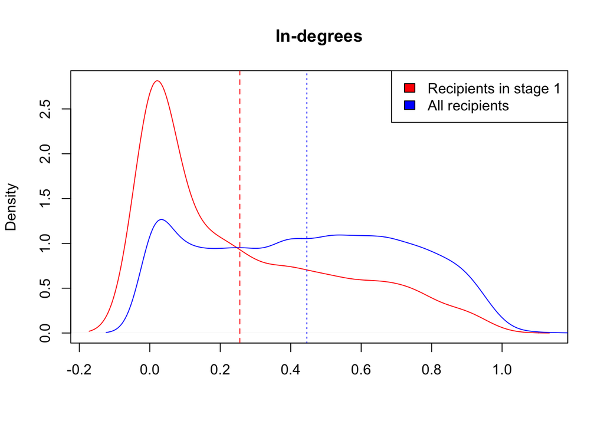

#### Calculate MLD counts

- For 100 tree simulations,
- load a dataframe of tip states
- select incident (stage 1) patients
- replicate Monte-Carlo sampling of MLD
- In `single.mc.mld.R`, function `single.mc.mld.ip` does:
1. from matrix of $W_{ij}$
2. split sets of $1:k_j$ donors per unique recipient $j$
3. initialize to 0 MLD count $m_1:m_i$ for all unique donors + $m_{i+1}$ for ‘outside source’
4. **for** each $j$,
5. **do** sample one of {$k_j$ donors, ‘outside source’}
   - with probabilities {$W_{ij}$, $(1 - \sum_j{W_{ij}})$}
   - $m_k = m_k + 1$
6. **end**

In baseline scenario, an average 6.838 % of donors have a non-zero values

#### Test if zero-inflated model provide better fit than logistic regression (MLD 0 vs >0)

- On first MC replicate of first baseline simulation,
- model `Y ~ young + ehi + risk`, with
  - Y either MLD count or binary (0 vs >0),
  - and young = age 1, ehi = stage 1
- “LOGIT” = logistic, “PO” = poisson, “NB” = neg binomial, “ZIPO” = zi_poisson, “ZINB” = zi_neg binomial

|  | LOGIT | PO | NB | ZIPO | ZINB |
| --- | --- | --- | --- | --- | --- |
| count_(Intercept) | -3.98 | -3.96 | -3.96 | -3.92 | -3.92 |
| count_young | -0.06 | -0.08 | -0.08 | 0.09 | 0.09 |
| count_ehi | -1.83 | -1.82 | -1.82 | -1.09 | -1.13 |
| count_risk | 0.41 | 0.39 | 0.39 | 0.35 | 0.35 |
| zero_(Intercept) |  |  |  | -6.11 | -9.46 |
| zero_young |  |  |  | 8.25 | 14.60 |
| zero_ehi |  |  |  | 10.45 | 16.76 |
| zero_risk |  |  |  | -3.74 | -6.76 |
| log-likelihood | -1468.80 | -1499.05 | -1498.98 | -1497.54 | -1497.54 |
| df | 4.00 | 4.00 | 5.00 | 8.00 | 9.00 |
| AIC | 2945.59 | 3006.11 | 3007.95 | 3011.08 | 3013.07 |

- Apparently, LOGIT model is the best (AIC and non-significant zero-inflation parameters)
- age non significant
- **not** being in EHI is associated with being a MLD
- risk 2 is also associated with being a MLD

#### Only LOGIT models

So, I apply a logistic model to all 100 simulations * 100 MC replicates, and count the number of p < 0.05 associations

Direction of coefficients estimates and number of p-values < 0.05

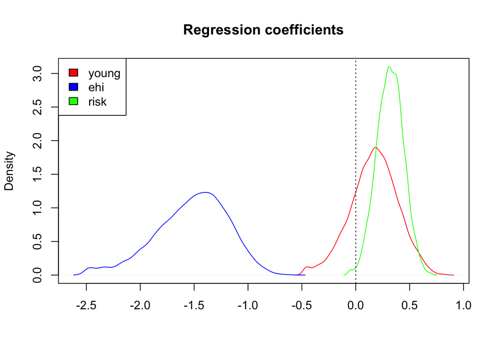

```r
####- look at distribution of coef estimate with SA method
get.coef(fits.logit_ba)
```

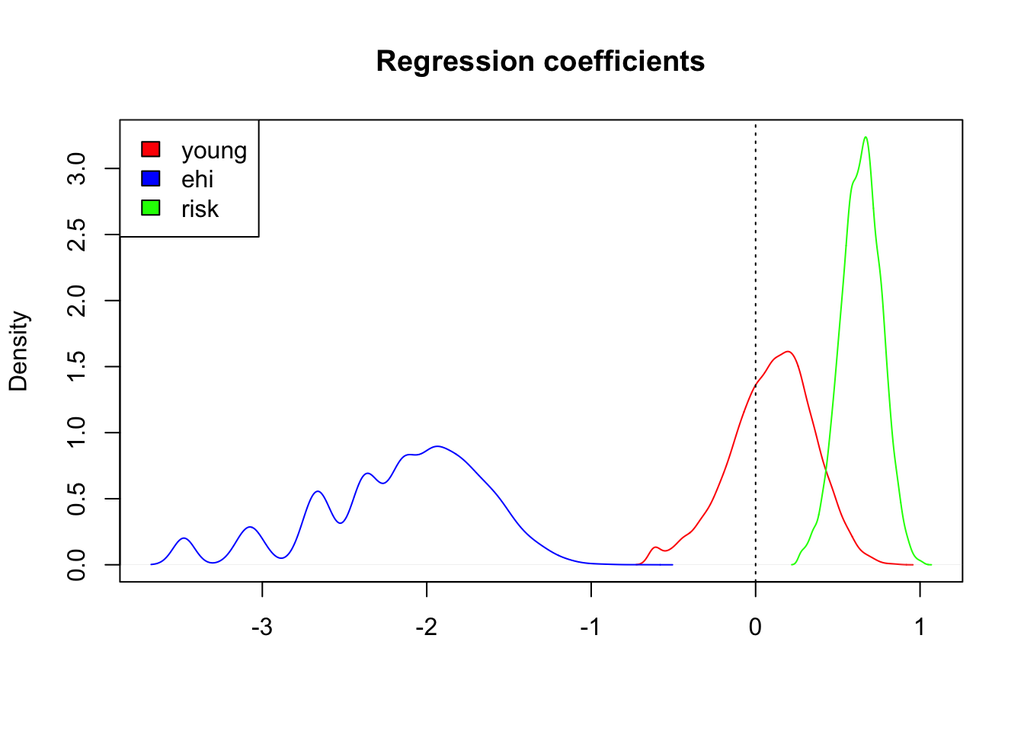

```r
get.coef(fits.logit_er)
```

```r
##- p-values for SA method
summary.p.values(fits.logit_ba)
```

```
##         young    ehi   risk
## Min.     0.00  99.00  16.00
## 1st Qu.  2.00 100.00  50.00
## Median   8.00 100.00  77.00
## Mean    15.43  99.99  69.65
## 3rd Qu. 18.00 100.00  92.00
## Max.    86.00 100.00 100.00
```

```r
summary.p.values(fits.logit_er)
```

```
##         young    ehi   risk
## Min.     0.00  92.00  90.00
## 1st Qu.  1.00  99.00 100.00
## Median   3.00 100.00 100.00
## Mean     8.91  99.38  99.74
## 3rd Qu.  8.00 100.00 100.00
## Max.    77.00 100.00 100.00
```

- Again, based on infector probabilities, **not** being EHI and risk level 2 increase chance of being MLD
- But that’s also the case in equal rate scenario
- Being young is generally not significant

#### Same results based on clustering

And do the same for cluster with MLD drawn from neighborhood:

In `single.mc.mld`,

1. from list of distances (undirected)
2. initialize to 0 MLD count $m_1:m_i$ for all unique nodes
3. **for** each node in stage 1 $j$,
4. **do** sample one of $n_j$ neighbors within distance threshold
   - with probabilities $1/n_j$
   - $m_k = m_k + 1$
5. **end**

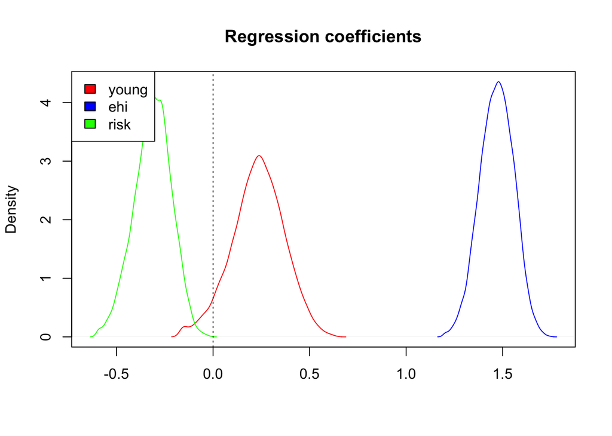

```r
##- look at distribution of coef estimate with CLUSTER
get.coef(fits.logit.clus_ba)
```

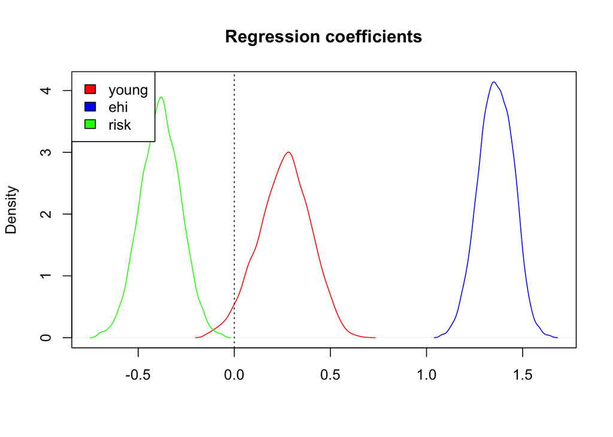

```r
get.coef(fits.logit.clus_er)
```

```r
##- p-values for CLUS method
summary.p.values(fits.logit.clus_ba)
```

```
##          young ehi   risk
## Min.      0.00 100  27.00
## 1st Qu.  17.75 100  93.00
## Median   37.50 100  99.00
## Mean     42.71 100  92.42
## 3rd Qu.  68.00 100 100.00
## Max.    100.00 100 100.00
```

```r
summary.p.values(fits.logit.clus_er)
```

```
##          young ehi   risk
## Min.      0.00 100  19.00
## 1st Qu.   7.75 100  99.75
## Median   46.00 100 100.00
## Mean     44.59 100  96.16
## 3rd Qu.  73.00 100 100.00
## Max.    100.00 100 100.00
```

- Based on neighborhood within 1.5% distance, being EHI, young age (in ~43% simulations) and **risk level 1** increase chance of being MLD
- Virtually no difference between scenarios

#### Conclusion

- zero-inflated models are not better than logistic reg
- MLD analyses are not able to distinguish the two scenarios regarding transmission by stage of infection
- Results confirm the bias of clustering towards early infection and young age
- strange result of risk (bug ?)